# Data Challenge #1: Dairy Cow Visualizations

Data Challenge #1: Dairy Cow Visualizations Ceyda Durmaz 09/30/2020

Link to GitHub Repository: https://github.com/cdurmaz569/Data_Science_I_Homework/tree/master/Homework_1

### Background

The United States Department of Agriculture (USDA) has collected statistics on the U.S. dairy condition from the past 15 months and annual statistics from the past 3 years. From this data, consumption of dairy products has changed in both amount and choice. These changes are apparent when examining dairy production, sales, and consumption over both the course of time and location.

### Load libraries, load data, and set theme

```r
# load libraries
libraries = c("readr", "ggplot2", "RColorBrewer", "knitr", "cowplot",
              "tidyverse", "reshape", "lubridate")
library.check <- lapply(libraries, FUN = function(x) {
    if (!require(x, character.only = TRUE)) {
      install.packages(x, dependencies = TRUE)
      library(x, character.only = TRUE)
    }
  }
)

# load data
setwd("~/Documents/Data_Science_I/Homework/Homework_1/")
clean.cheese <- read.csv("clean_cheese.csv")
fluid.milk.sales <- read.csv("fluid_milk_sales.csv")
milk.products.facets <- read.csv("milk_products_facts.csv")
milkcow.facts <- read.csv("milkcow_facts.csv")
state.milk.production <- read.csv("state_milk_production.csv")

# set theme for ggplot
theme_set(theme_classic())
theme.shrink <-   theme(axis.title.x = element_text(size = 8),
                        axis.title.y = element_text(size = 8))

# set palette to use
def.palette <- "Set1"
```

### Time Series: Production vs Sales of Milk from 1980 to 2014

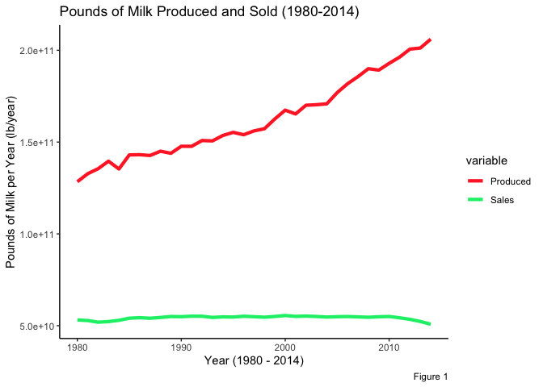

```r
# get total milk production (lbs)
milk.production <- milkcow.facts[,c(1,4)]

# get total milk product sales (lbs)
milk.sales <- fluid.milk.sales %>%
  filter(milk_type == "Total Production") %>% select(year, pounds)

# combine data into one dataframe for visualization
milk.processing.years <- milk.production %>%
  inner_join(milk.sales, by = "year")

# rename columns of dataframe and melt to input to ggplot
names(milk.processing.years) <- c("Year", "Produced", "Sales")

# get ratio of average of milk produced:sold
ratio.milk.process <- round(mean(milk.processing.years$Produced)/
  mean(milk.processing.years$Sales))

# melt data so each row is 'year-production/sale-pounds'
milk.processing.years <- melt(milk.processing.years, id.vars = "Year")

# time course line plot of milk processing over the years
ggplot(milk.processing.years, aes(x = Year)) +
  geom_line(aes(y = value, col = variable), size = 1.5) + # line plot
  scale_color_manual(labels = c("Produced", "Sales"), # change color of lines
                     values = c("Produced" = "firebrick1",
                                "Sales" = "springgreen2")) +
  labs(title = "Pounds of Milk Produced and Sold (1980-2014)", # add title
       x = "Year (1980 - 2014)", # change x axis label
       y = "Pounds of Milk per Year (lb/year)",
       caption = "Figure 1") # change y axis label
```

**Figure 1.** This plot shows the total milk production (‘Produced’, red) and milk product sold (‘Sales’, green) in pounds annually from 1980 to 2014. Compared to sales, an average of around 3 times more pounds of milk seem to be produced. While milk production has steadily increased over the 34 years, milk sales remain fairly unchanged from 1980 to 2010, before beginning to slightly drop after 2010.

### Trends in Milk Production Across US by region over Three Decades

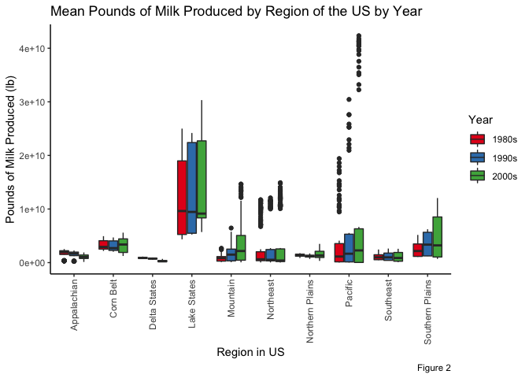

```r
# subset state.milk.production by decade
regions.80 <- state.milk.production %>% filter(year < 1990)
regions.90 <- state.milk.production %>% filter(year >= 1990 & year < 2000)
regions.00 <- state.milk.production %>% filter(year >= 2000)

# give each decade an identifier
regions.80$Decade <- "1980s"
regions.90$Decade <- "1990s"
regions.00$Decade <- "2000s"

# combine regions decade subsets and filter out states
regions.milk <- rbind(regions.80, regions.90, regions.00)
regions.milk <- regions.milk[,-c(2)]

# grouped boxplots
ggplot(regions.milk, aes(x = region, y = milk_produced, fill = factor(Decade))) +
  geom_boxplot() +
  scale_fill_brewer(palette = def.palette) +
  theme(axis.text.x = element_text(angle = 90, vjust = 0.5, hjust=1)) +
  labs(title = "Mean Pounds of Milk Produced by Region of the US by Year",
       x = "Region in US",
       y = "Pounds of Milk Produced (lb)",
       fill = "Year",
       caption = "Figure 2")
```

### Changes in Dairy Product Consumption per Person over Three Decades

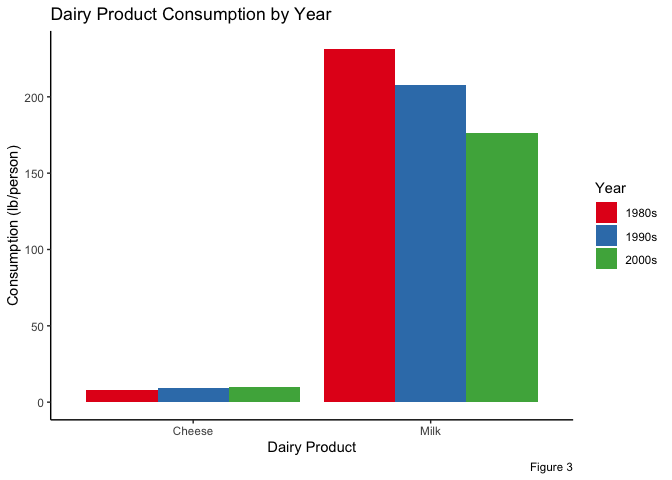

```r
# filter milk.products.facets and clean.cheese to get consumptions/person by year
milk.person.80 <- milk.products.facets %>% filter(year < 1990) %>% select(year, fluid_milk)
milk.person.90 <- milk.products.facets %>% filter(year >= 1990 & year < 2000) %>% select(year, fluid_milk)
milk.person.00 <- milk.products.facets %>% filter(year >= 2000) %>% select(year, fluid_milk)
cheese.person.80 <- clean.cheese %>% filter(Year < 1990) %>% select(Year, Cheddar)
cheese.person.90 <- clean.cheese %>% filter(Year >= 1990 & Year < 2000) %>% select(Year, Cheddar)
cheese.person.00 <- clean.cheese %>% filter(Year >= 2000) %>% select(Year, Cheddar)

# rename columns
names(milk.person.80) <- c("Year", "Consumption")
names(milk.person.90) <- c("Year", "Consumption")
names(milk.person.00) <- c("Year", "Consumption")
names(cheese.person.80) <- c("Year", "Consumption")
names(cheese.person.90) <- c("Year", "Consumption")
names(cheese.person.00) <- c("Year", "Consumption")

# give each decade an identifier
milk.person.80$Decade <- "1980s"
milk.person.90$Decade <- "1990s"
milk.person.00$Decade <- "2000s"
cheese.person.80$Decade <- "1980s"
cheese.person.90$Decade <- "1990s"
cheese.person.00$Decade <- "2000s"

# add group id to distinguish between milk and cheese data
milk.person.80$groupID <- "Milk"
milk.person.90$groupID <- "Milk"
milk.person.00$groupID <- "Milk"
cheese.person.80$groupID <- "Cheese"
cheese.person.90$groupID <- "Cheese"
cheese.person.00$groupID <- "Cheese"

# combine subsetted df by row
person.consumption <- rbind(milk.person.80, milk.person.90, milk.person.00,
                            cheese.person.80, cheese.person.90, cheese.person.00)

# grouped bar plot
ggplot(person.consumption, aes(x = groupID, y = Consumption, fill = factor(Decade))) +
  geom_bar(position = "dodge", stat = "summary", fun = "mean") +
  scale_fill_brewer(palette = def.palette) +
  labs(title = "Dairy Product Consumption by Year",
       x = "Dairy Product",
       y = "Consumption (lb/person)",
       fill = "Year",
       caption = "Figure 3")
```

**Figure 3.** This grouped barplot visualizes changes in mean consumption (lb/person) over three decades in two classes of dairy product: cheese and milk. Cheese consumption per person on average, while showing a very subtle increase each decade, reamined mostly unchanged. In comparison, the average consumption of milk per person shows a clear decrease each decade.

### Composition of Milk Products Sales by Decade

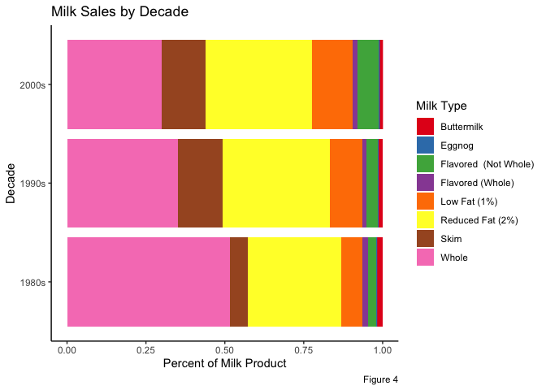

```r
# filter out Total Production form fluid.milk.sales
milk.sales <- fluid.milk.sales %>% filter(milk_type != "Total Production")

# subset by decade
milk.sales.80 <- milk.sales %>% filter(year >= 1980 & year < 1990)
milk.sales.90 <- milk.sales %>% filter(year >= 1990 & year < 2000)
milk.sales.00 <- milk.sales %>% filter(year >=2000)

# give each decade an identifier
milk.sales.80$Decade <- "1980s"
milk.sales.90$Decade <- "1990s"
milk.sales.00$Decade <- "2000s"

# combine milk sales decade subsets
milk.sales <- rbind(milk.sales.80, milk.sales.90, milk.sales.00)

# rename columns of milk.sales
names(milk.sales) <- c("Year", "Milk Type", "Pounds", "Decade")

# stacked bar plot
ggplot(milk.sales, aes(x = Decade, y = Pounds, fill = `Milk Type`)) +
  geom_bar(position = "fill", stat = "identity") +
  scale_fill_brewer(palette = def.palette) +
  coord_flip() +
  labs(title = "Milk Sales by Decade",
       x = "Decade",
       y = "Percent of Milk Product",
       caption = "Figure 4")
```

**Figure 4.** This stacked barplot shows the percent composition of milk sales over three decades. Of the eight types of milk, whole milk and reduced fat (2%) milk make up the majority of the sales. However, whole milk sales have been steadily decreasing with each decade, while skim milk and low fat (1%) milk sales hve increased. Sales in flavored whole milk and buttermilk remain mostly unchanged.

### Milk Cow Maintenance over Three Decades

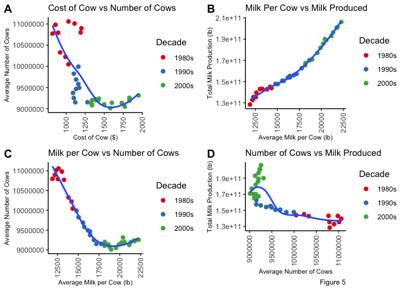

```r
# subset milkcow.facts by decade
milkcow.80 <- milkcow.facts %>% filter(year < 1990)
milkcow.90 <- milkcow.facts %>% filter(year >= 1990 & year < 2000)
milkcow.00 <- milkcow.facts %>% filter(year >= 2000)

# give each decade an identifier
milkcow.80$Decade <- "1980s"
milkcow.90$Decade <- "1990s"
milkcow.00$Decade <- "2000s"

# combine milkcow decade subsets
milkcow.cat <- rbind(milkcow.80, milkcow.90, milkcow.00)

# create scatterplots analyzing cows, milk production, and cost
scatter.1 <- ggplot(milkcow.cat, aes(x = milk_cow_cost_per_animal,
                                     y = avg_milk_cow_number)) +
  geom_point(aes(col = Decade), size = 2) +
  geom_smooth(method = "loess", se = F) +
  scale_color_brewer(palette = def.palette) +
  theme(axis.text.x = element_text(angle = 90, vjust = 0.5, hjust=1)) +
  labs(subtitle = "Cost of Cow vs Number of Cows",
       x = "Cost of Cow ($)",
       y = "Average Number of Cows") +
  theme.shrink

scatter.2 <- ggplot(milkcow.cat, aes(x = milk_per_cow,
                          y = milk_production_lbs)) +
  geom_point(aes(col = Decade), size = 2) +
  geom_smooth(method = "loess", se = F) +
  scale_color_brewer(palette = def.palette) +
  theme(axis.text.x = element_text(angle = 90, vjust = 0.5, hjust=1)) +
  labs(subtitle = "Milk Per Cow vs Milk Produced",
       x = "Average Milk per Cow (lb)",
       y = "Total Milk Production (lb)") +
  theme.shrink

scatter.3 <- ggplot(milkcow.cat, aes(x = milk_per_cow,
                          y = avg_milk_cow_number)) +
  geom_point(aes(col = Decade), size = 2) +
  geom_smooth(method = "loess", se = F) +
  scale_color_brewer(palette = def.palette) +
  theme(axis.text.x = element_text(angle = 90, vjust = 0.5, hjust=1)) +
  labs(subtitle = "Milk per Cow vs Number of Cows",
       x = "Average Milk per Cow (lb)",
       y = "Average Number of Cows") +
  theme.shrink

scatter.4 <- ggplot(milkcow.cat, aes(x = avg_milk_cow_number,
                        y = milk_production_lbs)) +
  geom_point(aes(col = Decade), size = 2) +
  geom_smooth(method = "loess", se = F) +
  scale_color_brewer(palette = def.palette) +
  theme(axis.text.x = element_text(angle = 90, vjust = 0.5, hjust=1)) +
  labs(subtitle = "Number of Cows vs Milk Produced",
       x = "Average Number of Cows",
       y = "Total Milk Production (lb)",
       caption = "Figure 5") +
  theme.shrink

plot_grid(scatter.1, scatter.2, scatter.3, scatter.4,
          labels = c("A", "B", "C", "D"),
          ncol = 2, nrow = 2)
```

**Figure 5.** These scatter plots show the correlation between various factors milk cow owning farmers have considered over three decades. **(A)** Over time, there has been a negative correlation with the increase in cost of cows and the drop in the average number of cows owned. **(B)** Despite the clear drop in cow ownership, there is a clear positive correlation between the average pounds of milk produced per cow and the total milk produced as time progresses. **(C)** As the average milk produced per cow could be a potential confounding variable in the relationship between cow cost and cow ownership shown in A, the average milk produced per cow was compared to the average number of cows and showed an almost identical negative correlation to A. **(D)** Interestingly, this information helps make sense of the seemingly contradicting negative correlation of cow ownership and total milk produced, because if the cows are producing more milk on average, farmers can own less cows.